# Project: No-show Appointments Data Analysis

## Exploratory Data Analysis

### Research Question 1: Does gender has any affect on keeping appointment rate?

```python
# Count values value for each gender
df['gender'].value_counts()
```

```
F    71840
M    38687
Name: gender, dtype: int64
```

```python
# Check for mean of no show for each gender
df.groupby('gender')['no_show'].mean()
```

```
gender
F    0.203146
M    0.199679
Name: no_show, dtype: float64
```

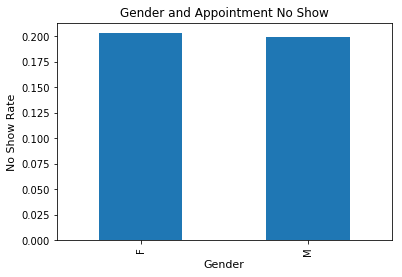

```python
df.groupby('gender')['no_show'].mean().plot(kind ='bar', title ='Gender and Appointment No Show')
plt.xlabel('Gender', fontsize=11)
plt.ylabel('No Show Rate', fontsize=11);
```

There are no significant different in rate of keeping medical appointment when comparing different genders.

### Research Question 2: Does ages has any effects on keeping medical appointment?

```python
df.age.mean()
```

```
37.088874211731067
```

```python
# Assign ages into four different groups
bin_edges = [-1, 12, 30, 50,115]
bin_names = ['child_age', 'young_age', 'middle_age', 'senior_age']
```

```python
# Create new a column for the age group
df['age_group'] = pd.cut(df['age'], bin_edges, labels=bin_names)
df.head()
```

|  | gender | age | hypertension | diabetes | alcoholism | handicap | sms_received | no_show | age_group |
| --- | --- | --- | --- | --- | --- | --- | --- | --- | --- |
| 0 | F | 62 | 1 | 0 | 0 | 0 | 0 | 0 | senior_age |
| 1 | M | 56 | 0 | 0 | 0 | 0 | 0 | 0 | senior_age |
| 2 | F | 62 | 0 | 0 | 0 | 0 | 0 | 0 | senior_age |
| 3 | F | 8 | 0 | 0 | 0 | 0 | 0 | 0 | child_age |
| 4 | F | 56 | 1 | 1 | 0 | 0 | 0 | 0 | senior_age |

```python
df.groupby('age_group')['no_show'].mean()
```

```
age_group
child_age     0.204744
young_age     0.251393
middle_age    0.207044
senior_age    0.161675
Name: no_show, dtype: float64
```

```
Text(0,0.5,'No Show Rate')
```

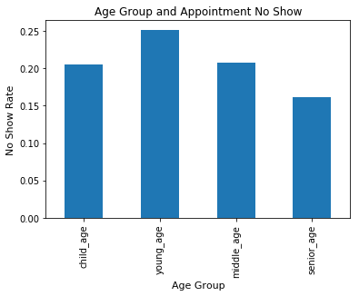

```python
df.groupby('age_group')['no_show'].mean().plot(kind ='bar', title ='Age Group and Appointment No Show')
plt.xlabel('Age Group', fontsize=11)
plt.ylabel('No Show Rate', fontsize=11)
```

Patient at the age between 12 to 30 is more likely to miss their appoinment, while patients that at the age of 50 or older will be more likely to keep their appoinment.

### Research Question 3: Would message reminder increase the chance of patient show up to their appointments?

```python
# Check the effectiveness of message reminder by using mean
df.groupby('sms_received')['no_show'].mean()
```

```
sms_received
0    0.167033
1    0.275745
Name: no_show, dtype: float64
```

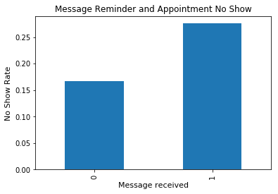

```python
df.groupby('sms_received')['no_show'].mean().plot('bar', title ='Message Reminder and Appointment No Show')
plt.xlabel('Message received', fontsize=11)
plt.ylabel('No Show Rate', fontsize=11);
```

Message reminder did not increase the number of patients showing up for their appoinments.

## Conclusions

> By analyzing appointment no-show based on patients’ age, gender and message reminder, the result has shown that:  
> - Gender does not affect weather a patient would miss their appointment.  
> - Patients at the age between 12 to 30 have higher chance of not showing up in their medical appointments, while patients who are at the age of 50 or older will be more likely to keep their appointments.  
> - Although message reminder was thought to help increasing the appointment showed up rate, statistic showed that message reminder did not play a major role.

#### Limitation

> There are some outliner in age where is min age is -1 and the max age is 115

```python
from subprocess import call
call(['python', '-m', 'nbconvert', 'Investigate_a_Dataset.ipynb'])
```

```
0
```